# Uber Report

Freddy Drennan

April 3, 2016

```r
library(ggplot2)
library(ggmap)
```

## Introduction

Ridesharing Works for Austin (RWFA) is a political group lobbying for City Ordinance No 20160217-001 to replace City Ordinance No 20151217-075. A petition began early in 2016 which collected over 65,000 votes. The primary goal of this section is to outline the arguments made by Ridesharing Works for Austin and explain the difference between the two ordinances. It will be shown that City Ordinance No. 20151217-075 is superior and that RWFA is using clever tactics to hoodwink Austintes into voting against their wishes.

RWFA claims the future of ridesharing is a stake as seen in the image below taken from [VoteProp1.com](http://voteprop1.com/).

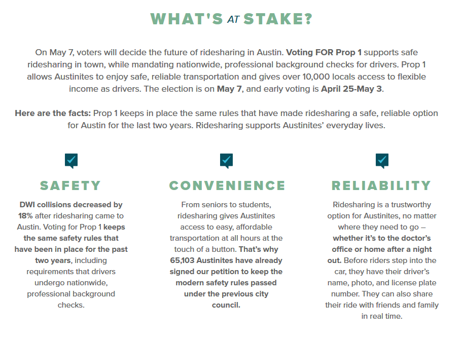

My first experience with the RWFA cround came began in early January, when a man came to my door and asked if I wished to “Keep Uber in Austin.” He explained, “Taxi companies are losing profits, and they’re lobbying to kick out companies like Uber and Lyft. We don’t this this is fair, do you mind signing the petition?” I signed his petition and he moved on to another home. It was not until later I found that his story was not entirely accurate. I hope to show as clearly as I can, what I have found on the issue at hand.

Show entries

Search:

|  | Date | DUIs | population |
| --- | --- | --- | --- |
| 1 | 2011-01-01 | 464 | 838779 |
| 2 | 2011-02-01 | 421 | 840834.861 |
| 3 | 2011-03-01 | 455 | 842890.722 |
| 4 | 2011-04-01 | 412 | 844946.583 |
| 5 | 2011-05-01 | 418 | 847002.444 |
| 6 | 2011-06-01 | 352 | 849058.305 |
| 7 | 2011-07-01 | 395 | 851114.166 |
| 8 | 2011-08-01 | 393 | 853170.027 |
| 9 | 2011-09-01 | 449 | 855225.888 |
| 10 | 2011-10-01 | 451 | 857281.749 |

Showing 1 to 10 of 62 entries

As you can see, there has been a decrease in DUI’s, however it is also important to note that the decrease began before Uber arrived into town, around 2013. Uber arrived in June 2014.

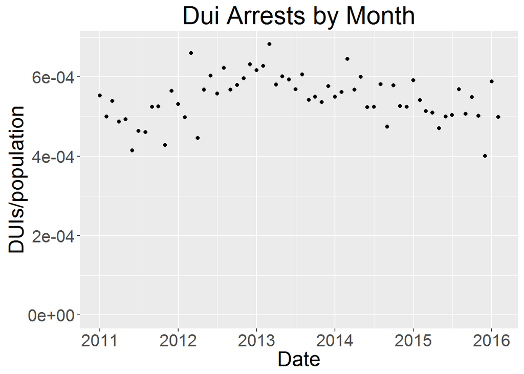

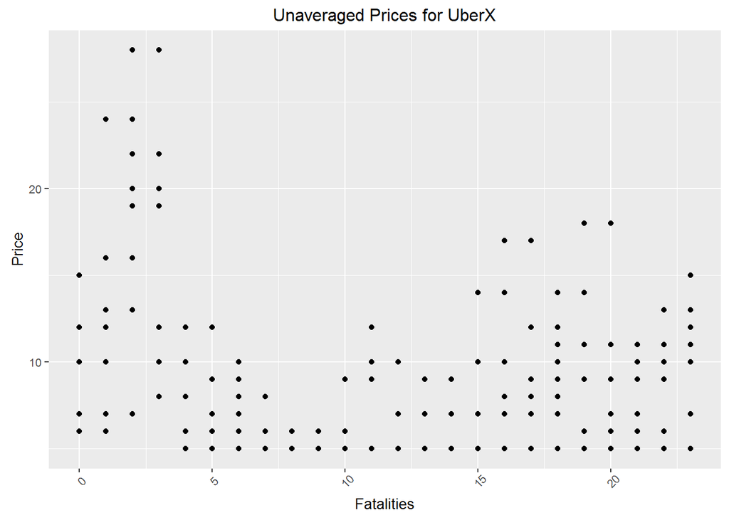

```r
p5 + theme(text = element_text(size=10),
        axis.text.x = element_text(angle=45, vjust=.75))
```

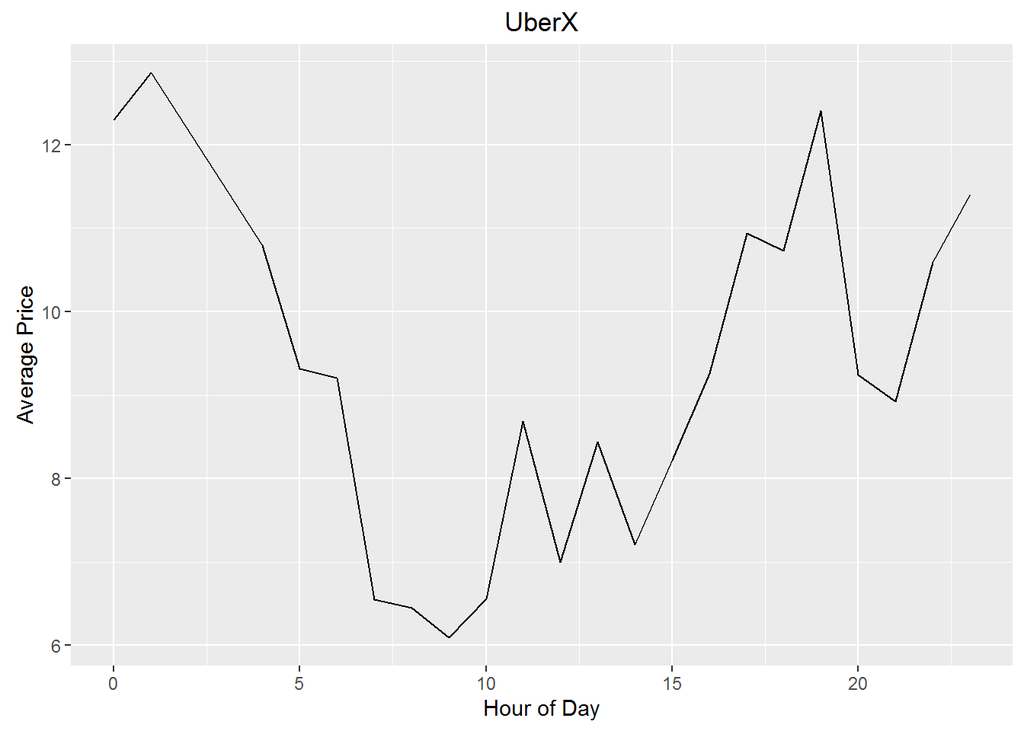

```r
p2
```

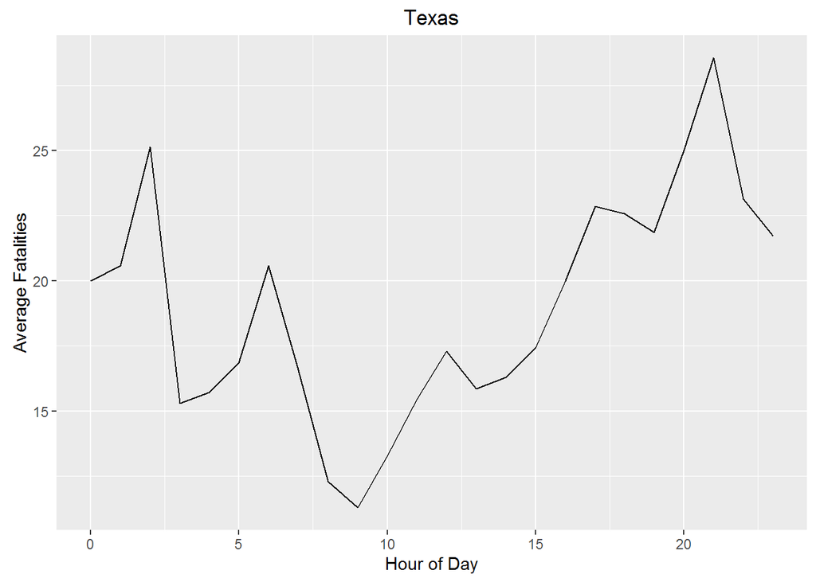

```r
p3
```

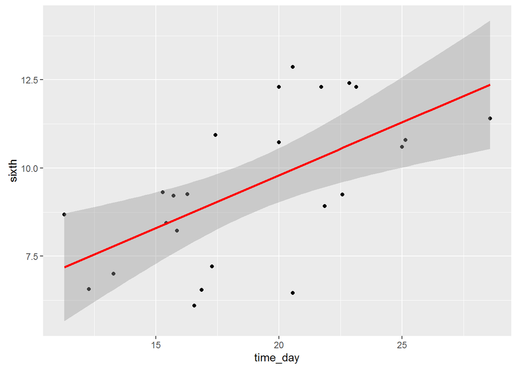

```r
p4
```

The data for average fatalities at a given time of the day is listed below.

Show entries

Search:

|  | Crash.Hour | mean |
| --- | --- | --- |
| 1 | 0 | 20 |
| 2 | 1 | 21 |
| 3 | 2 | 25 |
| 4 | 3 | 15 |
| 5 | 4 | 16 |
| 6 | 5 | 17 |
| 7 | 6 | 21 |
| 8 | 7 | 17 |
| 9 | 8 | 12 |
| 10 | 9 | 11 |

Showing 1 to 10 of 24 entries

My next step was to see if RWFA is presenting their information in a clear way. Under safety, they claim is that “Voting for Prop 1 keeps the same safety rules that have been in place for the past two years.” The claim suggests that the new proposition is making Austin safe. However, what might we find if we compare the old proposition to the new one?

Here is a list of sections from the old ordinance that have been removed:

Uber would no longer be required to coordinate with event officials in order to ensure riders are picked up in appropriate and safe locations.

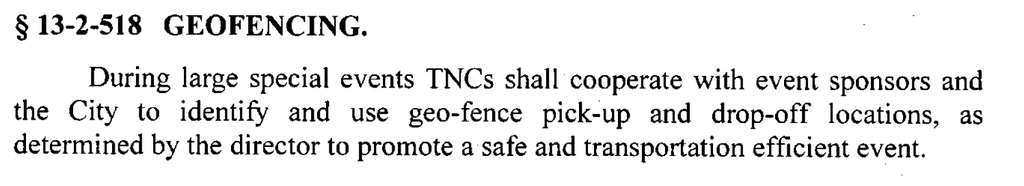

Uber drivers are no longer required to pick up individuals in a safe location away from traffic.

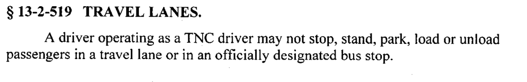

Uber does not have to be transparent about their insurance policies to their riders.

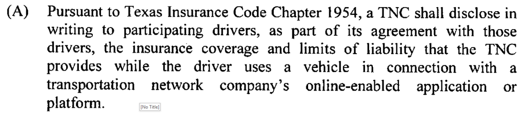

Uber does not have to tell their riders that they need to get better insurance.

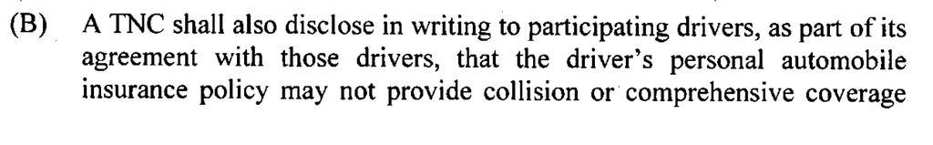

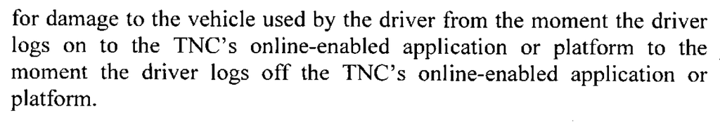

Uber will not have to report vital data to the city in order to evaluate the effectiveness of Uber in facilitiating a thriving transportation system in Austin.

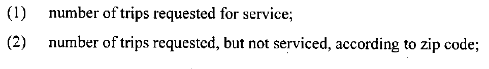

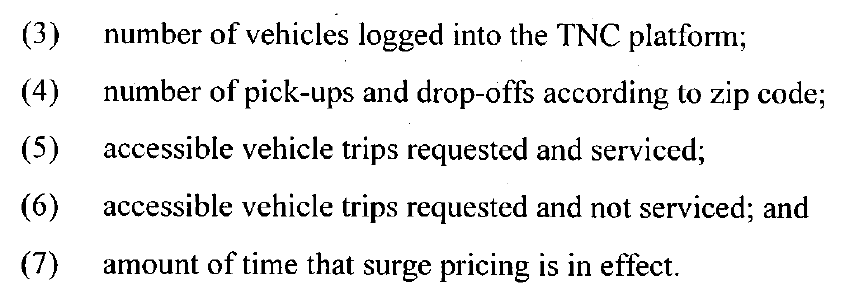

Uber will not have to accomodate individuals with disabilities or in need of wheelchair assistance. Uber has stated that they desire to, but the business model does not work well with accomodating individuals with special needs. This is because most individuals who become Uber drivers will not want to add the expensive equipment to their personal vehicles. This is precisely an instance where legislation helps for the benifit of Austin as a whole. You can see below the text and the difference in options between Uber and Taxis. Taxis appear to be more accomodating to different people and with Uber you’re choices are limited to how nice of a car you’ll ride in.

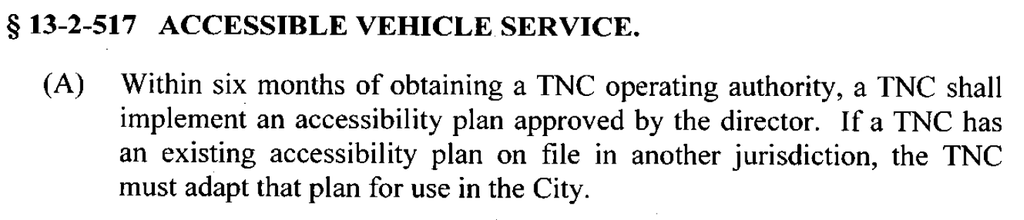

[figure not shown]

[figure not shown]

Uber will no longer be required to undergo face-to-face interviews with their employees.

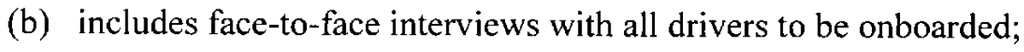

Here is the new ordinance on background checks

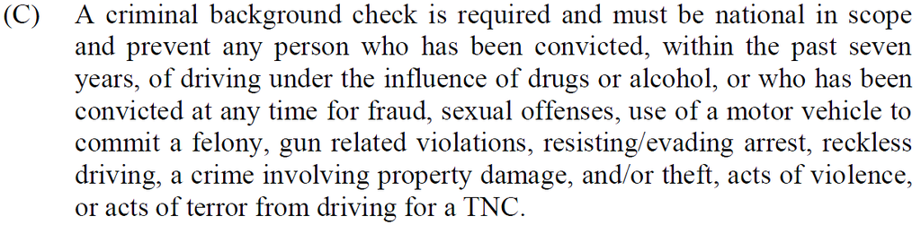

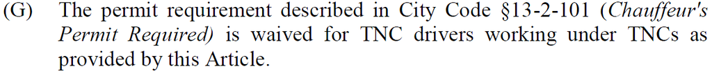

I began to wonder what a chauffers permit required. The difference is that Uber can hire people who have been convicted of selling or possesing drugs if they do not need to obtain chauffer’s permits.

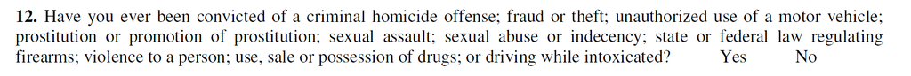

And last, for time sake; Uber will not be requred to reach out to those in low socioeconomic regions of Austin.

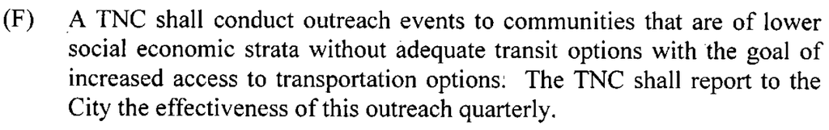

While Uber is marginally decreasing DUI’s, it appears that they are more concerned with profits. Not listed are various taxes that the company will no longer be paying, including a 1% fee on revenues toward the city.

Various data that I have collected and their plots are listed below.

# Fatal Crashes by City and Year

Show entries

Search:

|  | City | yr2006 | yr2007 | yr2008 | yr2009 | yr2010 | yr2011 | yr2012 | yr2013 | yr2014 | lat | lon |
| --- | --- | --- | --- | --- | --- | --- | --- | --- | --- | --- | --- | --- |
| 1 | ABILENE , TEXAS | 4 | 5 | 7 | 7 | 0 | 4 | 5 | 1 | 4 | 32.4487364 | -99.7331439 |
| 2 | ADDISON , TEXAS | 0 | 0 | 1 | 0 | 0 | 0 | 0 | 0 | 1 | 32.96179 | -96.8291685 |
| 3 | ALAMO , TEXAS | 0 | 0 | 0 | 0 | 0 | 0 | 0 | 1 | 0 | 26.1836854 | -98.1230638 |
| 4 | ALAMO HEIGHTS , TEXAS | 0 | 0 | 0 | 0 | 0 | 0 | 0 | 0 | 0 | 29.4849531 | -98.4658502 |
| 5 | ALICE , TEXAS | 0 | 0 | 0 | 0 | 0 | 0 | 0 | 0 | 0 | 27.7522487 | -98.0697249 |
| 6 | ALLEN , TEXAS | 0 | 0 | 0 | 0 | 1 | 0 | 1 | 2 | 2 | 33.1031744 | -96.6705503 |
| 7 | ALPINE , TEXAS | 0 | 0 | 0 | 0 | 0 | 0 | 0 | 0 | 0 | 30.3584919 | -103.6610115 |
| 8 | ALTON , TEXAS | 1 | 0 | 0 | 0 | 0 | 1 | 1 | 0 | 0 | 26.2872995 | -98.3133594 |
| 9 | ALVIN , TEXAS | 0 | 0 | 0 | 0 | 0 | 0 | 1 | 0 | 0 | 29.4238472 | -95.2441009 |
| 10 | AMARILLO , TEXAS | 8 | 6 | 4 | 2 | 5 | 1 | 7 | 13 | 4 | 35.2219971 | -101.8312969 |

Showing 1 to 10 of 380 entries

# Crash Statistics for Austin by Year

Show entries

Search:

|  | 34 |
| --- | --- |
| X2006.City | AUSTIN , TEXAS |
| X2006.Fatal.Crashes | 19 |
| X2006.Fatalities | 22 |
| X2006.Serious.Injury.Crashes | 315 |
| X2006.Serious.Injuries | 431 |
| X2006.Other.Injury.Crashes | 265 |
| X2006.Other.Injuries | 527 |
| X2006.Non.Injury.Crashes | 440 |
| X2006.Unknown.Severity.Crashes | 54 |
| X2006.Total.Crashes | 1093 |

Showing 1 to 10 of 109 entries

# Plot of DUI fatalities for the year 2011 by City

[figure not shown]

Show entries

Search:

|  | City | Fatal.Crashes | Fatalities | Incapacitating.Crashes | Incapacitating.Injuries | Non.Incapacitating.Crashes | Non.Incapacitating.Injuries | Possible.Injury.Crashes | Possible.Injuries | Non.Injury.Crashes | Non.Injuries | Unknown.Severity.Crashes | Unknown.Injuries | Total.Crashes | lat | lon |
| --- | --- | --- | --- | --- | --- | --- | --- | --- | --- | --- | --- | --- | --- | --- | --- | --- |
| 1 | ABBOTT , TEXAS | 0 | 0 | 0 | 0 | 0 | 0 | 0 | 0 | 1 | 1 | 0 | 0 | 1 | 31.8848809 | -97.0733361 |
| 2 | ABILENE , TEXAS | 4 | 4 | 9 | 10 | 17 | 21 | 11 | 20 | 60 | 135 | 1 | 1 | 102 | 32.4487364 | -99.7331439 |
| 3 | ADDISON , TEXAS | 1 | 1 | 1 | 2 | 6 | 6 | 2 | 2 | 15 | 30 | 0 | 0 | 25 | 32.96179 | -96.8291685 |
| 4 | ALAMO , TEXAS | 0 | 0 | 2 | 2 | 1 | 1 | 6 | 11 | 12 | 33 | 0 | 4 | 21 | 26.1836854 | -98.1230638 |
| 5 | ALAMO HEIGHTS , TEXAS | 0 | 0 | 1 | 1 | 0 | 0 | 3 | 4 | 1 | 3 | 0 | 0 | 5 | 29.4849531 | -98.4658502 |
| 6 | ALEDO , TEXAS | 0 | 0 | 0 | 0 | 0 | 0 | 0 | 0 | 1 | 2 | 0 | 0 | 1 | 32.6959643 | -97.6022471 |
| 7 | ALICE , TEXAS | 0 | 0 | 0 | 0 | 1 | 1 | 5 | 9 | 16 | 31 | 0 | 1 | 22 | 27.7522487 | -98.0697249 |
| 8 | ALLEN , TEXAS | 2 | 2 | 0 | 0 | 7 | 7 | 11 | 15 | 26 | 52 | 2 | 2 | 48 | 33.1031744 | -96.6705503 |
| 9 | ALPINE , TEXAS | 0 | 0 | 0 | 0 | 1 | 1 | 1 | 1 | 4 | 4 | 0 | 0 | 6 | 30.3584919 | -103.6610115 |
| 10 | ALTON , TEXAS | 0 | 0 | 0 | 0 | 0 | 0 | 2 | 4 | 2 | 10 | 0 | 0 | 4 | 26.2872995 | -98.3133594 |

Showing 1 to 10 of 712 entries

# DUI related deaths for Travis County by Age and year

Show entries

Search:

[output not shown]

Showing 1 to 10 of 44 entries

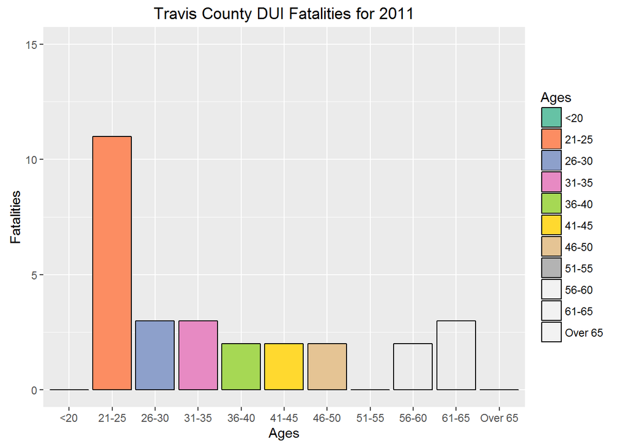

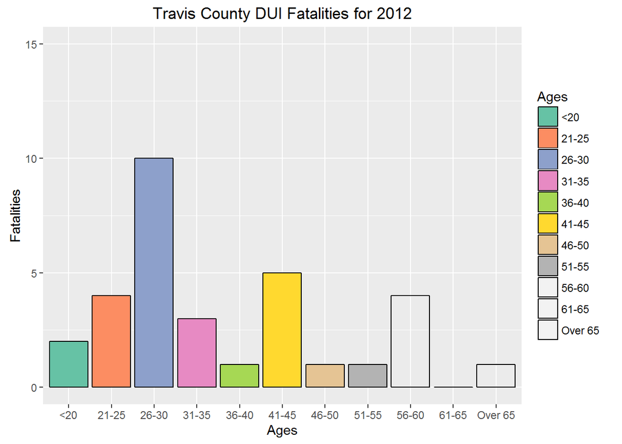

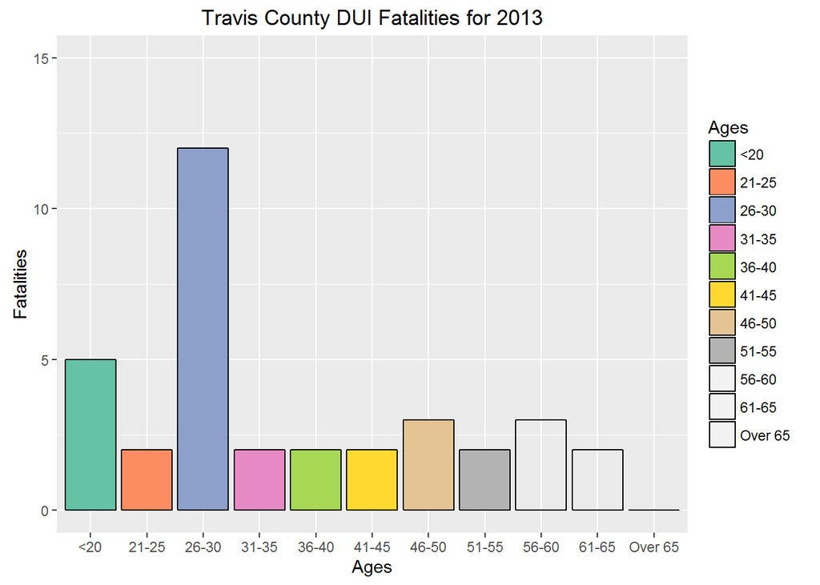

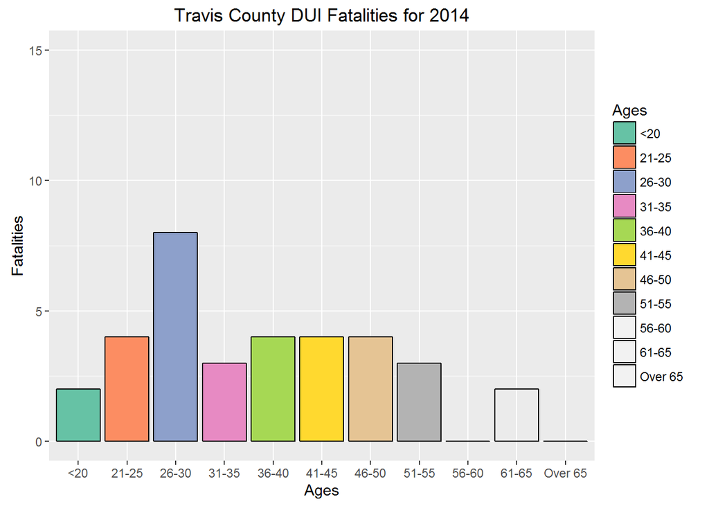

```
## 'data.frame':    5 obs. of  3 variables:
##  $ YEAR       : chr  "7/3/1905" "7/4/1905" "7/5/1905" "7/6/1905" ...
##  $ DWI.ARRESTS: int  5065 6007 6369 6155 5874
##  $ Population : int  1024266 1096661 1121968 1150996 1176558
```

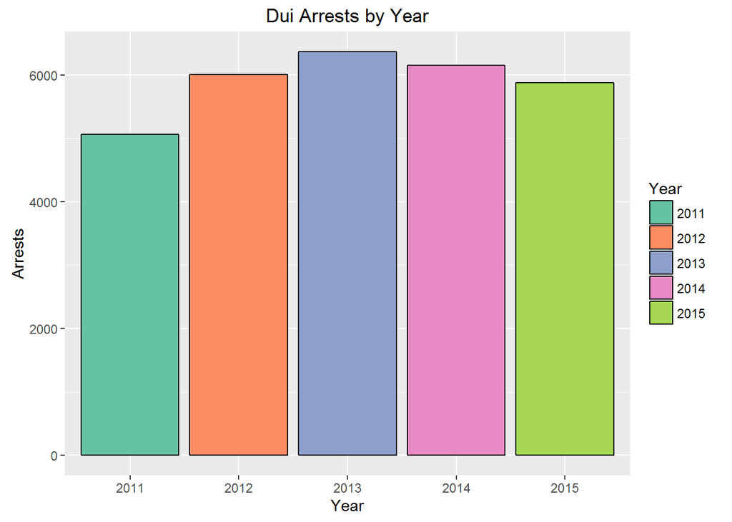

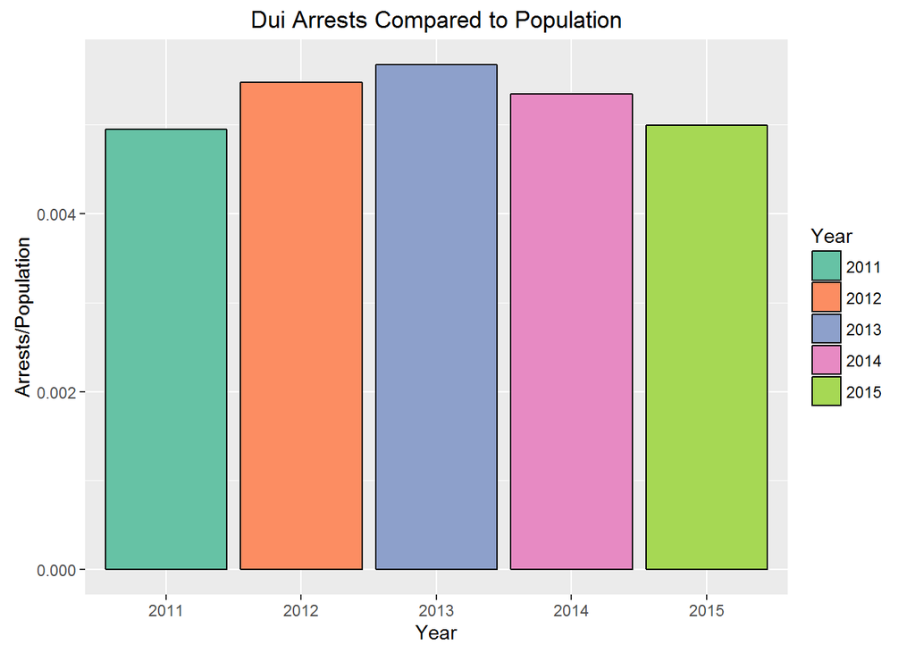